# Майнор "Интеллектуальный анализ данных"

# Курс "Прикладные задачи анализа данных"

## Лабораторная работа №2. RecSys

В рамках данной лабораторной работы вам предлагается решить задачу рекомендательной системы на основе следующих данных:

- **rating.csv** - рейтинги аниме по 10 бальной шкале
- **anime.csv** - описание items

Скачать данные можно [здесь](https://drive.google.com/drive/u/1/folders/1FarHUuqQq4tQSlERB9K8uEfZAZT9tQWv)

# Данные

Данные содержат информацию об предподчтениях 73,516 пользователей в 12,294 аниме. Каждый пользователь может добавить аниме и выставить рейтниг.

Anime.csv

- anime_id - идентификатор аниме (items)
- name - полное название аниме
- genre - категория/категории для аниме (разделены запятой).
- type - тип: movie, TV, OVA, etc.
- episodes - количество эпизодов (для экранизаций)
- rating - средний рейтинг по аниме.
- members - количество членов коммьюнити к аниме

Rating.csv

- user_id - идентификатор пользователя (users)
- anime_id - идентификатор аниме
- rating - рейтинг пользователя по аниме (-1 пользователь смотрел, но не оставил рейтинг).

### `Если вычеслительные ресурсы не позволяют решить задачу на всех данных, то необходимо это сделать на "сэмпле" данных (выбрав от 5% ids' для user и item). Этот же подход справедлив и для оценки работы алгоритомв`

```python
from google.colab import drive
drive.mount('/content/drive')
```

```python
import pandas as pd
import numpy as np
import matplotlib.pyplot as plt
import seaborn as sns
import matplotlib as mpl
import matplotlib.pylab as pylab
%matplotlib inline
pd.set_option('display.max_columns', 500)
mpl.style.use('ggplot')
sns.set_style('white')
pylab.rcParams['figure.figsize'] = 12,8

import warnings
warnings.filterwarnings('ignore')
```

```python
!unzip '/content/drive/MyDrive/archive (1).zip'
```

```
Archive:  /content/drive/MyDrive/archive (1).zip
  inflating: anime.csv
  inflating: rating.csv
```

```python
anime = pd.read_csv('anime.csv')
rating = pd.read_csv('rating.csv')

print (str(anime.shape))
print (anime.info())
```

```
(12294, 7)
<class 'pandas.core.frame.DataFrame'>
RangeIndex: 12294 entries, 0 to 12293
Data columns (total 7 columns):
 #   Column    Non-Null Count  Dtype
---  ------    --------------  -----
 0   anime_id  12294 non-null  int64
 1   name      12294 non-null  object
 2   genre     12232 non-null  object
 3   type      12269 non-null  object
 4   episodes  12294 non-null  object
 5   rating    12064 non-null  float64
 6   members   12294 non-null  int64
dtypes: float64(1), int64(2), object(4)
memory usage: 672.5+ KB
None
```

```python
print (str(rating.shape))
print (rating.info())
```

```
(7813737, 3)
<class 'pandas.core.frame.DataFrame'>
RangeIndex: 7813737 entries, 0 to 7813736
Data columns (total 3 columns):
 #   Column    Dtype
---  ------    -----
 0   user_id   int64
 1   anime_id  int64
 2   rating    int64
dtypes: int64(3)
memory usage: 178.8 MB
None
```

Теперь будем мерджить два датафрейма

```python
anime_fulldata=pd.merge(anime,rating,on='anime_id',suffixes= ['', '_user'])
anime_fulldata = anime_fulldata.rename(columns={'name': 'anime_title', 'rating_user': 'user_rating'})
anime_fulldata.head()
```

|  | anime_id | anime_title | genre | type | episodes | rating | members | user_id | user_rating |
| --- | --- | --- | --- | --- | --- | --- | --- | --- | --- |
| 0 | 32281 | Kimi no Na wa. | Drama, Romance, School, Supernatural | Movie | 1 | 9.37 | 200630 | 99 | 5 |
| 1 | 32281 | Kimi no Na wa. | Drama, Romance, School, Supernatural | Movie | 1 | 9.37 | 200630 | 152 | 10 |
| 2 | 32281 | Kimi no Na wa. | Drama, Romance, School, Supernatural | Movie | 1 | 9.37 | 200630 | 244 | 10 |
| 3 | 32281 | Kimi no Na wa. | Drama, Romance, School, Supernatural | Movie | 1 | 9.37 | 200630 | 271 | 10 |
| 4 | 32281 | Kimi no Na wa. | Drama, Romance, School, Supernatural | Movie | 1 | 9.37 | 200630 | 278 | -1 |

## Необходимо сделать:

### Задание №1 : Exploratory analysis (2 балла):

- Распределение числа пользователей по количеству взаимодействий
- Разпределение числа "айтемов" по количеству взаимодействий
- Распределение числа рейтингов, средних рейтингов по пользователям, по "айтемам"
- и т.д. (бонус)

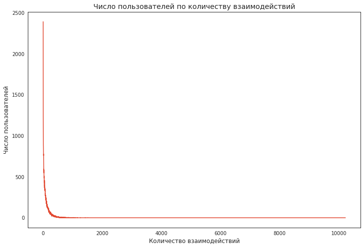

```python
rating.groupby('user_id')['anime_id'].count().value_counts().sort_index().plot(
    title = 'Число пользователей по количеству взаимодействий',
    xlabel = 'Количество взаимодействий',
    ylabel = 'Число пользователей'
)
```

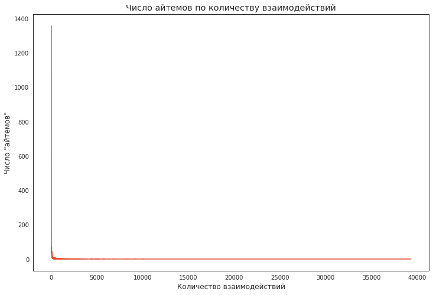

```python
rating.groupby('anime_id')['user_id'].count().value_counts().sort_index().plot(
    title = 'Число айтемов по количеству взаимодействий',
    xlabel = 'Количество взаимодействий',
    ylabel = 'Число "айтемов"'
)
```

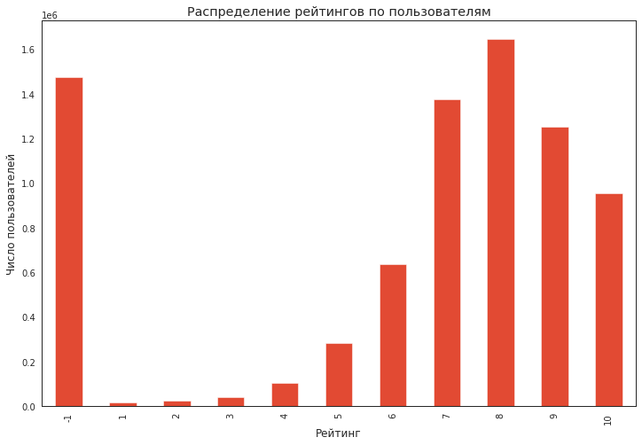

```python
rating.groupby('rating')['user_id'].count().plot(kind='bar',
    title = 'Распределение рейтингов по пользователям',
    xlabel = 'Рейтинг',
    ylabel = 'Число пользователей'
)
```

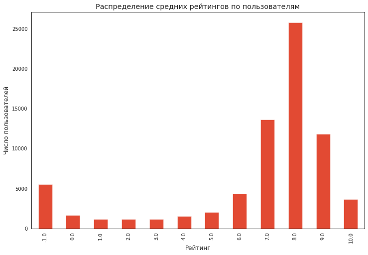

```python
rating.groupby('user_id')['rating'].mean().round(decimals=0).value_counts().sort_index().plot(kind='bar',
    title = 'Распределение средних рейтингов по пользователям',
    xlabel = 'Рейтинг',
    ylabel = 'Число пользователей'
)
```

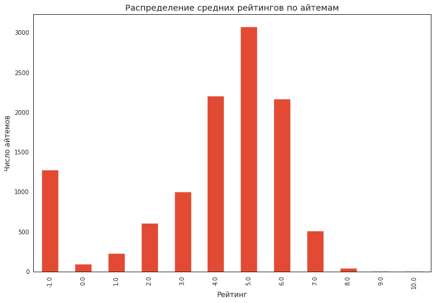

```python
rating.groupby('anime_id')['rating'].mean().round(decimals=0).value_counts().sort_index().plot(kind='bar',
    title = 'Распределение средних рейтингов по айтемам',
    xlabel = 'Рейтинг',
    ylabel = 'Число айтемов'
)
```

### Задание №2 : Оценить разреженность данных по рейтингу (1/2 балла)

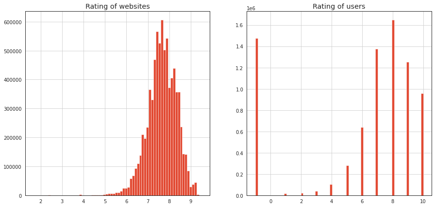

```python
plt.figure(figsize = (15, 7))
plt.subplot(1,2,1)
anime_fulldata['rating'].hist(bins=70)
plt.title("Rating of websites")
plt.subplot(1,2,2)
anime_fulldata['user_rating'].hist(bins=70)
plt.title("Rating of users")
```

- Основное распределение рейтингов в диапазоне 6-10
- Самый частый рейтинг 7.5-8
- В рейтинге пользователей есть выбросы со значением -1, надо их обработать

### Задание №3 : Разделить данные на тренировочные и валидационные (1/2 балла)

Предобработаем данные и поделим их на тренировочные и валидационные

```python
anime_feature=anime_fulldata.copy()
anime_feature["user_rating"].replace({-1: np.nan}, inplace=True)
anime_feature.head()
```

|  | anime_id | anime_title | genre | type | episodes | rating | members | user_id | user_rating |
| --- | --- | --- | --- | --- | --- | --- | --- | --- | --- |
| 0 | 32281 | Kimi no Na wa. | Drama, Romance, School, Supernatural | Movie | 1 | 9.37 | 200630 | 99 | 5.0 |
| 1 | 32281 | Kimi no Na wa. | Drama, Romance, School, Supernatural | Movie | 1 | 9.37 | 200630 | 152 | 10.0 |
| 2 | 32281 | Kimi no Na wa. | Drama, Romance, School, Supernatural | Movie | 1 | 9.37 | 200630 | 244 | 10.0 |
| 3 | 32281 | Kimi no Na wa. | Drama, Romance, School, Supernatural | Movie | 1 | 9.37 | 200630 | 271 | 10.0 |
| 4 | 32281 | Kimi no Na wa. | Drama, Romance, School, Supernatural | Movie | 1 | 9.37 | 200630 | 278 | NaN |

```python
anime_feature = anime_feature.dropna(axis = 0, how ='any')
anime_feature.isnull().sum()
```

```
anime_id       0
anime_title    0
genre          0
type           0
episodes       0
rating         0
members        0
user_id        0
user_rating    0
dtype: int64
```

```python
anime_feature['user_id'].value_counts()
```

```
42635    3747
53698    2905
57620    2689
59643    2632
51693    2620
         ...
41324       1
11199       1
19041       1
26082       1
62930       1
Name: user_id, Length: 69600, dtype: int64
```

Есть пользователи, которые голосовали слишком мало. Возьмем минимум 200 голосов, чтобы засчитывать голоса пользователя

```python
counts = anime_feature['user_id'].value_counts()
anime_feature = anime_feature[anime_feature['user_id'].isin(counts[counts >= 200].index)]
```

```python
from sklearn.model_selection import train_test_split
train, test = train_test_split(anime_feature, test_size=0.2, random_state=52)
```

### Задание №4 : Решить задачу на основе предложения всем юзерам наиболее популярных item (1 балл)

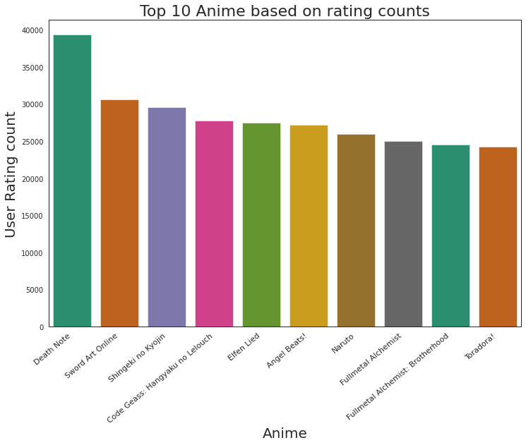

```python
combine_anime_rating = anime_fulldata.dropna(axis = 0, subset = ['anime_title'])
anime_ratingCount = (combine_anime_rating.
     groupby(by = ['anime_title'])['user_rating'].
     count().
     reset_index().rename(columns = {'rating': 'totalRatingCount'})
    [['anime_title', 'user_rating']]
    )


top10_animerating=anime_ratingCount[['anime_title', 'user_rating']].sort_values(by = 'user_rating',ascending = False).head(10)
ax=sns.barplot(x="anime_title", y="user_rating", data=top10_animerating, palette="Dark2")
ax.set_xticklabels(ax.get_xticklabels(), fontsize=11, rotation=40, ha="right")
ax.set_title('Top 10 Anime based on rating counts',fontsize = 22)
ax.set_xlabel('Anime',fontsize = 20)
ax.set_ylabel('User Rating count', fontsize = 20)
```

### Задание №5 : Решить задачу на основе коллоборативной фильтрации (2 балла)

- Реализовать один из методов коллоборативной фильтрации SVD, SVD++, ALS, ALS with implicit feedback

```python
pip install surprise
```

```
     |████████████████████████████████| 11.8 MB 4.8 MB/s
```

```python
from surprise import Dataset,Reader,SVD
from surprise.model_selection import cross_validate
```

```python
reader = Reader(rating_scale=(1,10))
data = Dataset.load_from_df(rating[['user_id', 'anime_id', 'rating']], reader)
```

```python
svd = SVD()
cross_validate(svd, data, measures=['RMSE', 'MAE'], cv=5, verbose=True)
```

[output not shown]

[output cut: 26 more lines]

[output not shown]

### Задание №6 Решить задачу на основе контент-based подхода, выбрав один из методов решения (2 балла):

- На основание векторов с факторизационной матрицы
- При помощи "ембеддингов" item'ов

Сначала подчистим тайтлы

```python
import re
def text_cleaning(text):
    text = re.sub(r'&quot;', '', text)
    text = re.sub(r'.hack//', '', text)
    text = re.sub(r'&#039;', '', text)
    text = re.sub(r'A&#039;s', '', text)
    text = re.sub(r'I&#039;', 'I\'', text)
    text = re.sub(r'&amp;', 'and', text)

    return text

anime['name'] = anime['name'].apply(text_cleaning)
```

```python
from sklearn.feature_extraction.text import TfidfVectorizer


tfv = TfidfVectorizer(min_df=3,  max_features=None,
            strip_accents='unicode', analyzer='word',token_pattern=r'\w{1,}',
            ngram_range=(1, 3),
            stop_words = 'english')

anime['genre'] = anime['genre'].fillna('')
genres_str = anime['genre'].str.split(',').astype(str)
tfv_matrix = tfv.fit_transform(genres_str)
```

```python
from sklearn.metrics.pairwise import sigmoid_kernel

sig = sigmoid_kernel(tfv_matrix, tfv_matrix)
```

```python
indices = pd.Series(anime.index, index=anime['name']).drop_duplicates()
```

Сигмоида возвращает метрику схожести тайтлов, с помощью enumerate я превращаю ее в список и отсортировав получаю топ-10 похожих тайтлов

```python
def give_rec(title, sig=sig):
    idx = indices[title]
    sig_scores = list(enumerate(sig[idx]))
    sig_scores = sorted(sig_scores, key=lambda x: x[1], reverse=True)
    sig_scores = sig_scores[1:11]
    anime_indices = [i[0] for i in sig_scores]
    return pd.DataFrame({'Anime name': anime['name'].iloc[anime_indices].values,
                                 'Rating': anime['rating'].iloc[anime_indices].values})
```

```python
give_rec('Death Note')
```

|  | Anime name | Rating |
| --- | --- | --- |
| 0 | Death Note Rewrite | 7.84 |
| 1 | Mousou Dairinin | 7.74 |
| 2 | Higurashi no Naku Koro ni Kai | 8.41 |
| 3 | Higurashi no Naku Koro ni Rei | 7.56 |
| 4 | Bloody Night | 4.26 |
| 5 | Higurashi no Naku Koro ni | 8.17 |
| 6 | Shigofumi | 7.62 |
| 7 | Himitsu: The Revelation | 7.42 |
| 8 | Monster | 8.72 |
| 9 | Hikari to Mizu no Daphne | 6.87 |

### Задание №7 Оценить работу алгоритмов выбрав одну из метрик, сделать вывод по результатам работы (2 балла):

- MAP@k
- NDCG@k
- MRR

`Бонус (1 балл) - дополнительные графики и характеристики в EDA и правильно сделанные выводы`

# `Дедлайн - 08 июня 23:59`